# Mortgage Probability Default RF GBM ROC with selected data-1

## Learning Objectives

- Develop a function: if a block of code will be re-used several times, develop it as a function to avoid coding errors.
- ROC/AUC
- VARImp
- Train and test your model with a small dataset.
- Model with the entire dataset when there is no error.
- Keep your notebook clean and readable.
- Random forest
- Gradient boosting

### Load the data

```python
import numpy as np
import datetime
import pandas as pd
import matplotlib.pyplot as plt
#import seaborn as sns
import warnings
warnings.filterwarnings('ignore')
```

```python
data = pd.read_csv("//Users/Chriskuo/Downloads/XYZloan_default_selected_vars.csv")
```

```python
from sklearn.model_selection import train_test_split
train, test = train_test_split(
     data, test_size=0.40, random_state=42)
```

```python
train.shape
```

```
(48000, 90)
```

```python
var = pd.DataFrame(train.dtypes)
var.head(10)
```

|  | 0 |
| --- | --- |
| Unnamed: 0 | int64 |
| Unnamed: 0.1 | int64 |
| Unnamed: 0.1.1 | int64 |
| id | int64 |
| loan_default | int64 |
| AP001 | int64 |
| AP002 | int64 |
| AP003 | int64 |
| AP004 | int64 |
| AP005 | object |

```python
var = pd.DataFrame(train.dtypes).reset_index()
var.head()
```

|  | index | 0 |
| --- | --- | --- |
| 0 | Unnamed: 0 | int64 |
| 1 | Unnamed: 0.1 | int64 |
| 2 | Unnamed: 0.1.1 | int64 |
| 3 | id | int64 |
| 4 | loan_default | int64 |

```python
var.columns = ['varname','dtype']
var.head(10)
```

|  | varname | dtype |
| --- | --- | --- |
| 0 | Unnamed: 0 | int64 |
| 1 | Unnamed: 0.1 | int64 |
| 2 | Unnamed: 0.1.1 | int64 |
| 3 | id | int64 |
| 4 | loan_default | int64 |
| 5 | AP001 | int64 |
| 6 | AP002 | int64 |
| 7 | AP003 | int64 |
| 8 | AP004 | int64 |
| 9 | AP005 | object |

```python
var['source'] = var['varname'].str[:2]
var.head()
```

|  | varname | dtype | source |
| --- | --- | --- | --- |
| 0 | Unnamed: 0 | int64 | Un |
| 1 | Unnamed: 0.1 | int64 | Un |
| 2 | Unnamed: 0.1.1 | int64 | Un |
| 3 | id | int64 | id |
| 4 | loan_default | int64 | lo |

```python
var['source'].value_counts()
```

```
CD    36
TD    24
AP     9
CR     8
PA     6
Un     3
MB     2
id     1
lo     1
Name: source, dtype: int64
```

```python
# "AP004" is a bad data field and should be removed.
MB_list = list(var[var['source']=='MB']['varname'])
AP_list = list(var[(var['source']=='AP') & (var['varname']!='AP004')]['varname'])
TD_list = list(var[var['source']=='TD']['varname'])
CR_list = list(var[var['source']=='CR']['varname'])
PA_list = list(var[var['source']=='PA']['varname'])
CD_list = list(var[var['source']=='CD']['varname'])
AP_list
```

```
['AP001', 'AP002', 'AP003', 'AP005', 'AP006', 'AP007', 'AP008', 'AP009']
```

```python
train['loan_default'].value_counts(dropna=False)
```

```
0    38736
1     9264
Name: loan_default, dtype: int64
```

### Learning objective 1: H2O

- If you encounter errors, [this page](https://h2o-release.s3.amazonaws.com/h2o/rel-yates/5/index.html) may help.

```python
pip install h2o
```

[output not shown]

```python
import h2o
h2o.init()
```

```
Checking whether there is an H2O instance running at http://localhost:54321 ..... not found.
Attempting to start a local H2O server...
  Java Version: openjdk version "1.8.0_152-release"; OpenJDK Runtime Environment (build 1.8.0_152-release-1056-b12); OpenJDK 64-Bit Server VM (build 25.152-b12, mixed mode)
  Starting server from /opt/anaconda3/envs/AD/lib/python3.8/site-packages/h2o/backend/bin/h2o.jar
  Ice root: /var/folders/jw/wyhtzlf94zbgtpf9g_n5tryr0000gn/T/tmpxvdw33bx
  JVM stdout: /var/folders/jw/wyhtzlf94zbgtpf9g_n5tryr0000gn/T/tmpxvdw33bx/h2o_chriskuo_started_from_python.out
  JVM stderr: /var/folders/jw/wyhtzlf94zbgtpf9g_n5tryr0000gn/T/tmpxvdw33bx/h2o_chriskuo_started_from_python.err
  Server is running at http://127.0.0.1:54321
Connecting to H2O server at http://127.0.0.1:54321 ... successful.
```

| H2O_cluster_uptime: | 03 secs |
| --- | --- |
| H2O_cluster_timezone: | America/New_York |
| H2O_data_parsing_timezone: | UTC |
| H2O_cluster_version: | 3.30.1.3 |
| H2O_cluster_version_age: | 28 days, 19 hours and 58 minutes |
| H2O_cluster_name: | H2O_from_python_chriskuo_btbqz0 |
| H2O_cluster_total_nodes: | 1 |
| H2O_cluster_free_memory: | 1.778 Gb |
| H2O_cluster_total_cores: | 4 |
| H2O_cluster_allowed_cores: | 4 |
| H2O_cluster_status: | accepting new members, healthy |
| H2O_connection_url: | http://127.0.0.1:54321 |
| H2O_connection_proxy: | {"http": null, "https": null} |
| H2O_internal_security: | False |
| H2O_API_Extensions: | Amazon S3, XGBoost, Algos, AutoML, Core V3, TargetEncoder, Core V4 |
| Python_version: | 3.8.2 final |

```python
from h2o.estimators.gbm import H2OGradientBoostingEstimator
from h2o.estimators.random_forest import H2ORandomForestEstimator
```

```python
target='loan_default'
```

### Learning objective 2: Modeling best practices

- When you model, you should run with a small sample dataset
- Try to write repeating code in a function

```python
train_smpl = train.sample(frac=0.1, random_state=1)
test_smpl = test.sample(frac=0.1, random_state=1)
train_hex = h2o.H2OFrame(train_smpl)
test_hex = h2o.H2OFrame(test_smpl)
```

```
Parse progress: |█████████████████████████████████████████████████████████| 100%
Parse progress: |█████████████████████████████████████████████████████████| 100%
```

```python
predictors = CR_list + TD_list + AP_list + MB_list + CR_list + PA_list
```

```python
rf_v1 = H2ORandomForestEstimator(
        model_id = 'rf_v1',
        ntrees = 300,
        nfolds=10,
        min_rows=100,
        seed=1234)
rf_v1.train(predictors,target,training_frame=train_hex)
```

```
drf Model Build progress: |███████████████████████████████████████████████| 100%
```

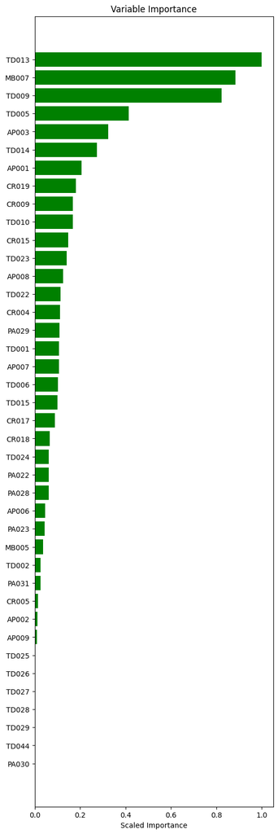

```python
def VarImp(model_name):

    from sklearn.metrics import roc_curve,auc
    from sklearn.metrics import average_precision_score
    from sklearn.metrics import precision_recall_curve
    import matplotlib.pyplot as plt

    # plot the variable importance
    plt.rcdefaults()
    variables = model_name._model_json['output']['variable_importances']['variable']
    y_pos = np.arange(len(variables))
    fig, ax = plt.subplots(figsize = (6,len(variables)/2))
    scaled_importance = model_name._model_json['output']['variable_importances']['scaled_importance']
    ax.barh(y_pos,scaled_importance,align='center',color='green')
    ax.set_yticks(y_pos)
    ax.set_yticklabels(variables)
    ax.invert_yaxis()
    ax.set_xlabel('Scaled Importance')
    ax.set_title('Variable Importance')
    plt.show()

VarImp(rf_v1)
```

```python
predictions = rf_v1.predict(test_hex)
predictions.head()
test_scores = test_hex['loan_default'].cbind(predictions).as_data_frame()
test_scores.head()
```

```
drf prediction progress: |████████████████████████████████████████████████| 100%
```

|  | loan_default | predict |
| --- | --- | --- |
| 0 | 0 | 0.275145 |
| 1 | 0 | 0.155382 |
| 2 | 0 | 0.119975 |
| 3 | 0 | 0.230445 |
| 4 | 0 | 0.120803 |

```python
def createGains(model):
    predictions = model.predict(test_hex)
    test_scores = test_hex['loan_default'].cbind(predictions).as_data_frame()

    #sort on prediction (descending), add id, and decile for groups containing 1/10 of datapoints
    test_scores = test_scores.sort_values(by='predict',ascending=False)
    test_scores['row_id'] = range(0,0+len(test_scores))
    test_scores['decile'] = ( test_scores['row_id'] / (len(test_scores)/10) ).astype(int)
    #see count by decile
    test_scores.loc[test_scores['decile'] == 10]=9
    test_scores['decile'].value_counts()

    #create gains table
    gains = test_scores.groupby('decile')['loan_default'].agg(['count','sum'])
    gains.columns = ['count','actual']
    gains

    #add features to gains table
    gains['non_actual'] = gains['count'] - gains['actual']
    gains['cum_count'] = gains['count'].cumsum()
    gains['cum_actual'] = gains['actual'].cumsum()
    gains['cum_non_actual'] = gains['non_actual'].cumsum()
    gains['percent_cum_actual'] = (gains['cum_actual'] / np.max(gains['cum_actual'])).round(2)
    gains['percent_cum_non_actual'] = (gains['cum_non_actual'] / np.max(gains['cum_non_actual'])).round(2)
    gains['if_random'] = np.max(gains['cum_actual']) /10
    gains['if_random'] = gains['if_random'].cumsum()
    gains['lift'] = (gains['cum_actual'] / gains['if_random']).round(2)
    gains['K_S'] = np.abs( gains['percent_cum_actual'] -  gains['percent_cum_non_actual'] ) * 100
    gains['gain']=(gains['cum_actual']/gains['cum_count']*100).round(2)
    gains = pd.DataFrame(gains)
    return(gains)

createGains(rf_v1)
```

```
drf prediction progress: |████████████████████████████████████████████████| 100%
```

| decile | count | actual | non_actual | cum_count | cum_actual | cum_non_actual | percent_cum_actual | percent_cum_non_actual | if_random | lift | K_S | gain |
| --- | --- | --- | --- | --- | --- | --- | --- | --- | --- | --- | --- | --- |
| 0 | 320 | 99 | 221 | 320 | 99 | 221 | 0.16 | 0.08 | 60.0 | 1.65 | 8.0 | 30.94 |
| 1 | 320 | 92 | 228 | 640 | 191 | 449 | 0.32 | 0.17 | 120.0 | 1.59 | 15.0 | 29.84 |
| 2 | 320 | 77 | 243 | 960 | 268 | 692 | 0.45 | 0.27 | 180.0 | 1.49 | 18.0 | 27.92 |
| 3 | 320 | 60 | 260 | 1280 | 328 | 952 | 0.55 | 0.37 | 240.0 | 1.37 | 18.0 | 25.62 |
| 4 | 320 | 64 | 256 | 1600 | 392 | 1208 | 0.65 | 0.46 | 300.0 | 1.31 | 19.0 | 24.50 |
| 5 | 320 | 53 | 267 | 1920 | 445 | 1475 | 0.74 | 0.57 | 360.0 | 1.24 | 17.0 | 23.18 |
| 6 | 320 | 40 | 280 | 2240 | 485 | 1755 | 0.81 | 0.68 | 420.0 | 1.15 | 13.0 | 21.65 |
| 7 | 320 | 57 | 263 | 2560 | 542 | 2018 | 0.90 | 0.78 | 480.0 | 1.13 | 12.0 | 21.17 |
| 8 | 320 | 34 | 286 | 2880 | 576 | 2304 | 0.96 | 0.89 | 540.0 | 1.07 | 7.0 | 20.00 |
| 9 | 320 | 24 | 296 | 3200 | 600 | 2600 | 1.00 | 1.00 | 600.0 | 1.00 | 0.0 | 18.75 |

```python
def ROC_AUC(my_result,df,target):
    from sklearn.metrics import roc_curve,auc
    from sklearn.metrics import average_precision_score
    from sklearn.metrics import precision_recall_curve
    import matplotlib.pyplot as plt

    # ROC
    y_actual = df[target].as_data_frame()
    y_pred = my_result.predict(df).as_data_frame()
    fpr = list()
    tpr = list()
    roc_auc = list()
    fpr,tpr,_ = roc_curve(y_actual,y_pred)
    roc_auc = auc(fpr,tpr)

    # Precision-Recall
    average_precision = average_precision_score(y_actual,y_pred)

    print('')
    print('   * ROC curve: The ROC curve plots the true positive rate vs. the false rositive sate')
    print('')
    print('	  * The area under the curve (AUC): A value between 0.5 (random) and 1.0 (perfect), measuring the prediction accuracy')
    print('')
    print('   * Recall (R) = The number of true positives / (the number of true positives + the number of false negatives)')
    print('')

    # plotting
    plt.figure(figsize=(10,4))

    # ROC
    plt.subplot(1,2,1)
    plt.plot(fpr,tpr,color='darkorange',lw=2,label='ROC curve (aare=%0.2f)' % roc_auc)
    plt.plot([0,1],[0,1],color='navy',lw=3,linestyle='--')
    plt.xlim([0.0,1.0])
    plt.ylim([0.0,1.05])
    plt.xlabel('False Positive Rate')
    plt.ylabel('True Positive Rate')
    plt.title('Receiver operating characteristic: AUC={0:0.4f}'.format(roc_auc))
    plt.legend(loc='lower right')

    # Precision-Recall
    plt.subplot(1,2,2)
    precision,recall,_ = precision_recall_curve(y_actual,y_pred)
    plt.step(recall,precision,color='b',alpha=0.2,where='post')
    plt.fill_between(recall,precision,step='post',alpha=0.2,color='b')
    plt.xlabel('Recall')
    plt.ylabel('Precision')
    plt.ylim([0.0,1.05])
    plt.xlim([0.0,1.0])
    plt.title('Precision-Recall curve: PR={0:0.4f}'.format(average_precision))
    plt.show()
```

```
drf prediction progress: |████████████████████████████████████████████████| 100%

   * ROC curve: The ROC curve plots the true positive rate vs. the false rositive sate

	  * The area under the curve (AUC): A value between 0.5 (random) and 1.0 (perfect), measuring the prediction accuracy

   * Recall (R) = The number of true positives / (the number of true positives + the number of false negatives)
```

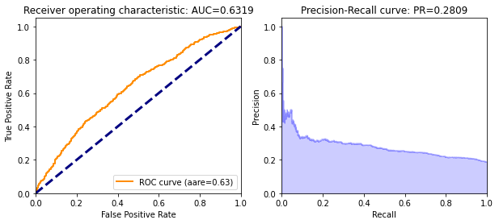

```python
ROC_AUC(rf_v1,test_hex,'loan_default')
```

```python
rf_v2 = H2ORandomForestEstimator(
        model_id = 'rf_v2',
        ntrees = 300,
        nfolds=10,
        min_rows=100,
        seed=1234)
rf_v2.train(predictors,target,training_frame=train_hex)
```

```
drf Model Build progress: |███████████████████████████████████████████████| 100%
```

```python
createGains(rf_v2)
```

```
drf prediction progress: |████████████████████████████████████████████████| 100%
```

| decile | count | actual | non_actual | cum_count | cum_actual | cum_non_actual | percent_cum_actual | percent_cum_non_actual | if_random | lift | K_S | gain |
| --- | --- | --- | --- | --- | --- | --- | --- | --- | --- | --- | --- | --- |
| 0 | 320 | 99 | 221 | 320 | 99 | 221 | 0.16 | 0.08 | 60.0 | 1.65 | 8.0 | 30.94 |
| 1 | 320 | 92 | 228 | 640 | 191 | 449 | 0.32 | 0.17 | 120.0 | 1.59 | 15.0 | 29.84 |
| 2 | 320 | 77 | 243 | 960 | 268 | 692 | 0.45 | 0.27 | 180.0 | 1.49 | 18.0 | 27.92 |
| 3 | 320 | 60 | 260 | 1280 | 328 | 952 | 0.55 | 0.37 | 240.0 | 1.37 | 18.0 | 25.62 |
| 4 | 320 | 64 | 256 | 1600 | 392 | 1208 | 0.65 | 0.46 | 300.0 | 1.31 | 19.0 | 24.50 |
| 5 | 320 | 53 | 267 | 1920 | 445 | 1475 | 0.74 | 0.57 | 360.0 | 1.24 | 17.0 | 23.18 |
| 6 | 320 | 40 | 280 | 2240 | 485 | 1755 | 0.81 | 0.68 | 420.0 | 1.15 | 13.0 | 21.65 |
| 7 | 320 | 57 | 263 | 2560 | 542 | 2018 | 0.90 | 0.78 | 480.0 | 1.13 | 12.0 | 21.17 |
| 8 | 320 | 34 | 286 | 2880 | 576 | 2304 | 0.96 | 0.89 | 540.0 | 1.07 | 7.0 | 20.00 |
| 9 | 320 | 24 | 296 | 3200 | 600 | 2600 | 1.00 | 1.00 | 600.0 | 1.00 | 0.0 | 18.75 |

### Learning objective 4: 10-fold Cross Validation

[figure not shown]

### Learning objective 4: Use H2O's "balance_classes"

- The balance_classes option can be used to balance the class distribution. When enabled, H2O will either undersample the majority classes or oversample the minority classes.
- Note that the resulting model will also correct the final probabilities (“undo the sampling”) using a monotonic transform, so the predicted probabilities of the first model will differ from a second model. However, because AUC only cares about ordering, it won’t be affected.
- See [this H2O page](https://docs.h2o.ai/h2o/latest-stable/h2o-docs/data-science/algo-params/balance_classes.html).

```python
rf_v3 = H2ORandomForestEstimator(
        model_id = 'rf_v3',
        ntrees = 300,
        nfolds=10,
        min_rows=100,
        balance_classes = True,
        seed=1234)
rf_v3.train(predictors,target,training_frame=train_hex)
```

```
drf Model Build progress: |███████████████████████████████████████████████| 100%
```

```
drf prediction progress: |████████████████████████████████████████████████| 100%

   * ROC curve: The ROC curve plots the true positive rate vs. the false rositive sate

	  * The area under the curve (AUC): A value between 0.5 (random) and 1.0 (perfect), measuring the prediction accuracy

   * Recall (R) = The number of true positives / (the number of true positives + the number of false negatives)
```

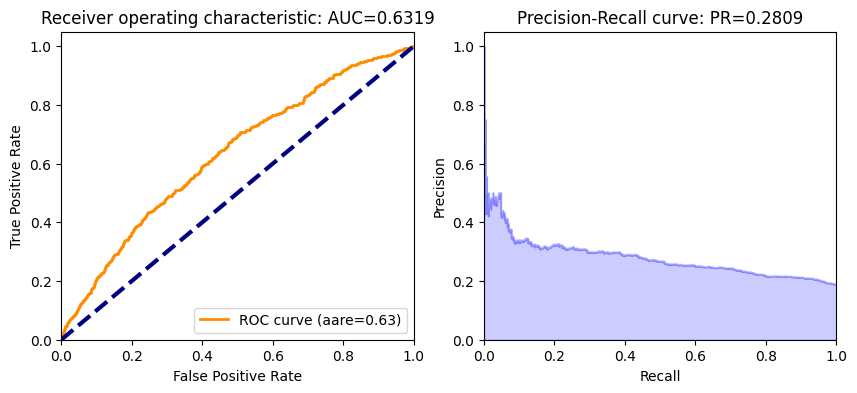

```python
ROC_AUC(rf_v3,test_hex,'loan_default')
```

```python
createGains(rf_v3)
```

```
drf prediction progress: |████████████████████████████████████████████████| 100%
```

| decile | count | actual | non_actual | cum_count | cum_actual | cum_non_actual | percent_cum_actual | percent_cum_non_actual | if_random | lift | K_S | gain |
| --- | --- | --- | --- | --- | --- | --- | --- | --- | --- | --- | --- | --- |
| 0 | 320 | 99 | 221 | 320 | 99 | 221 | 0.16 | 0.08 | 60.0 | 1.65 | 8.0 | 30.94 |
| 1 | 320 | 92 | 228 | 640 | 191 | 449 | 0.32 | 0.17 | 120.0 | 1.59 | 15.0 | 29.84 |
| 2 | 320 | 77 | 243 | 960 | 268 | 692 | 0.45 | 0.27 | 180.0 | 1.49 | 18.0 | 27.92 |
| 3 | 320 | 60 | 260 | 1280 | 328 | 952 | 0.55 | 0.37 | 240.0 | 1.37 | 18.0 | 25.62 |
| 4 | 320 | 64 | 256 | 1600 | 392 | 1208 | 0.65 | 0.46 | 300.0 | 1.31 | 19.0 | 24.50 |
| 5 | 320 | 53 | 267 | 1920 | 445 | 1475 | 0.74 | 0.57 | 360.0 | 1.24 | 17.0 | 23.18 |
| 6 | 320 | 40 | 280 | 2240 | 485 | 1755 | 0.81 | 0.68 | 420.0 | 1.15 | 13.0 | 21.65 |
| 7 | 320 | 57 | 263 | 2560 | 542 | 2018 | 0.90 | 0.78 | 480.0 | 1.13 | 12.0 | 21.17 |
| 8 | 320 | 34 | 286 | 2880 | 576 | 2304 | 0.96 | 0.89 | 540.0 | 1.07 | 7.0 | 20.00 |
| 9 | 320 | 24 | 296 | 3200 | 600 | 2600 | 1.00 | 1.00 | 600.0 | 1.00 | 0.0 | 18.75 |

### Learning objective 5: Undersampling

- [Using Under-Sampling Techniques for Extremely Imbalanced Data](https://towardsdatascience.com/sampling-techniques-for-extremely-imbalanced-data-part-i-under-sampling-a8dbc3d8d6d8)
- [imblearn](https://imbalanced-learn.readthedocs.io/en/stable/generated/imblearn.datasets.make_imbalance.html)

```python
y = data[target]
X = data.drop(target,axis=1)
y.dtypes
```

```
dtype('int64')
```

```python
y1_cnt = data[target].sum()
y1_cnt
```

```
15488
```

```python
N = 2
y0_cnt = y1_cnt * N
y0_cnt
```

```
30976
```

```python
pip install imblearn
```

```
  Using cached imblearn-0.0-py2.py3-none-any.whl (1.9 kB)
  Using cached imbalanced_learn-0.7.0-py3-none-any.whl (167 kB)
```

```python
from imblearn.datasets import make_imbalance
X_rs, y_rs = make_imbalance(X, y,
                            sampling_strategy={1:y1_cnt , 0:  y0_cnt},
                            random_state=0)
X_rs = pd.DataFrame(X_rs)
y_rs = pd.DataFrame(y_rs)
```

```python
y_rs = data[data[target]==1]
X_rs = data[data[target]==0].sample(n=y0_cnt)
smpl = pd.concat([X_rs,y_rs])
smpl_hex = h2o.H2OFrame(smpl)
```

```
Parse progress: |█████████████████████████████████████████████████████████| 100%
```

```python
rf_v4 = H2ORandomForestEstimator(
        model_id = 'rf_v4',
        ntrees = 300,
        nfolds=10,
        min_rows=100,
        seed=1234)
rf_v4.train(predictors,target,training_frame=smpl_hex)
```

```
drf Model Build progress: |███████████████████████████████████████████████| 100%
```

```
drf prediction progress: |████████████████████████████████████████████████| 100%

   * ROC curve: The ROC curve plots the true positive rate vs. the false rositive sate

	  * The area under the curve (AUC): A value between 0.5 (random) and 1.0 (perfect), measuring the prediction accuracy

   * Recall (R) = The number of true positives / (the number of true positives + the number of false negatives)
```

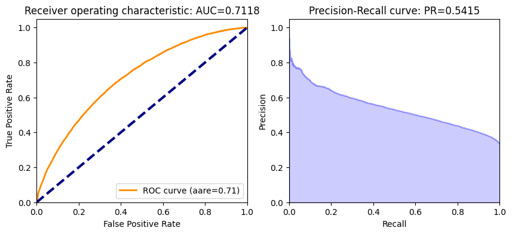

```python
ROC_AUC(rf_v4,smpl_hex,'loan_default')
```

```
drf prediction progress: |████████████████████████████████████████████████| 100%

   * ROC curve: The ROC curve plots the true positive rate vs. the false rositive sate

	  * The area under the curve (AUC): A value between 0.5 (random) and 1.0 (perfect), measuring the prediction accuracy

   * Recall (R) = The number of true positives / (the number of true positives + the number of false negatives)
```

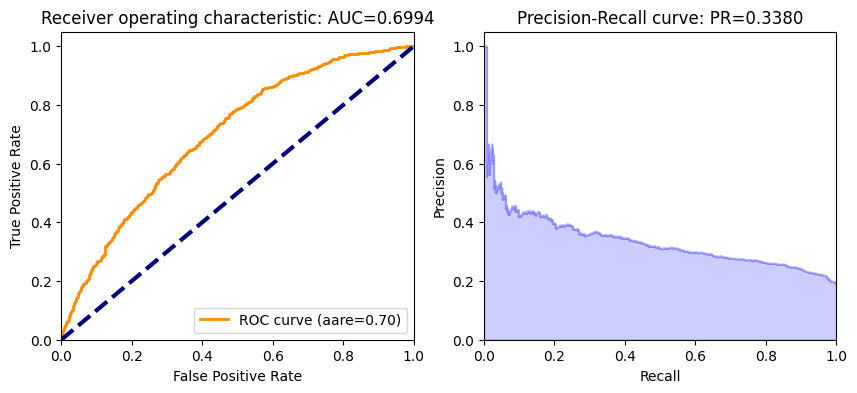

```python
ROC_AUC(rf_v4,test_hex,'loan_default')
```

```python
createGains(rf_v4)
```

```
drf prediction progress: |████████████████████████████████████████████████| 100%
```

| decile | count | actual | non_actual | cum_count | cum_actual | cum_non_actual | percent_cum_actual | percent_cum_non_actual | if_random | lift | K_S | gain |
| --- | --- | --- | --- | --- | --- | --- | --- | --- | --- | --- | --- | --- |
| 0 | 320 | 122 | 198 | 320 | 122 | 198 | 0.20 | 0.08 | 60.0 | 2.03 | 12.0 | 38.12 |
| 1 | 320 | 103 | 217 | 640 | 225 | 415 | 0.38 | 0.16 | 120.0 | 1.88 | 22.0 | 35.16 |
| 2 | 320 | 73 | 247 | 960 | 298 | 662 | 0.50 | 0.25 | 180.0 | 1.66 | 25.0 | 31.04 |
| 3 | 320 | 78 | 242 | 1280 | 376 | 904 | 0.63 | 0.35 | 240.0 | 1.57 | 28.0 | 29.38 |
| 4 | 320 | 64 | 256 | 1600 | 440 | 1160 | 0.73 | 0.45 | 300.0 | 1.47 | 28.0 | 27.50 |
| 5 | 320 | 57 | 263 | 1920 | 497 | 1423 | 0.83 | 0.55 | 360.0 | 1.38 | 28.0 | 25.89 |
| 6 | 320 | 43 | 277 | 2240 | 540 | 1700 | 0.90 | 0.65 | 420.0 | 1.29 | 25.0 | 24.11 |
| 7 | 320 | 30 | 290 | 2560 | 570 | 1990 | 0.95 | 0.77 | 480.0 | 1.19 | 18.0 | 22.27 |
| 8 | 320 | 18 | 302 | 2880 | 588 | 2292 | 0.98 | 0.88 | 540.0 | 1.09 | 10.0 | 20.42 |
| 9 | 320 | 12 | 308 | 3200 | 600 | 2600 | 1.00 | 1.00 | 600.0 | 1.00 | 0.0 | 18.75 |

### GBM

```python
gbm_v1 = H2OGradientBoostingEstimator(
        model_id = 'gbm_v1',
        seed=1234)
gbm_v1.train(predictors,target,training_frame=train_hex)
```

```
gbm Model Build progress: |███████████████████████████████████████████████| 100%
```

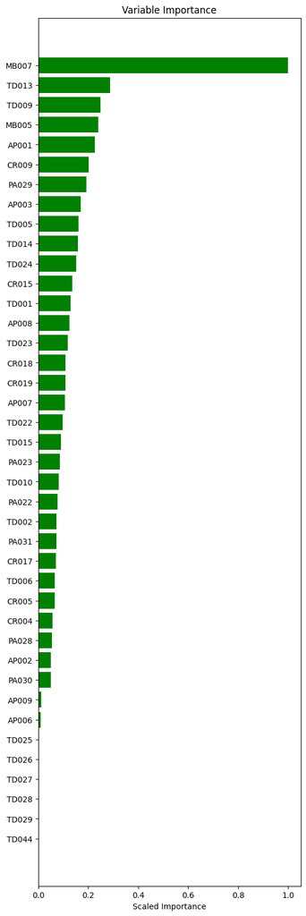

```python
VarImp(gbm_v1)
```

```python
createGains(gbm_v1)
```

```
gbm prediction progress: |████████████████████████████████████████████████| 100%
```

| decile | count | actual | non_actual | cum_count | cum_actual | cum_non_actual | percent_cum_actual | percent_cum_non_actual | if_random | lift | K_S | gain |
| --- | --- | --- | --- | --- | --- | --- | --- | --- | --- | --- | --- | --- |
| 0 | 320 | 95 | 225 | 320 | 95 | 225 | 0.16 | 0.09 | 60.0 | 1.58 | 7.0 | 29.69 |
| 1 | 320 | 82 | 238 | 640 | 177 | 463 | 0.30 | 0.18 | 120.0 | 1.48 | 12.0 | 27.66 |
| 2 | 320 | 67 | 253 | 960 | 244 | 716 | 0.41 | 0.28 | 180.0 | 1.36 | 13.0 | 25.42 |
| 3 | 320 | 67 | 253 | 1280 | 311 | 969 | 0.52 | 0.37 | 240.0 | 1.30 | 15.0 | 24.30 |
| 4 | 320 | 64 | 256 | 1600 | 375 | 1225 | 0.62 | 0.47 | 300.0 | 1.25 | 15.0 | 23.44 |
| 5 | 320 | 59 | 261 | 1920 | 434 | 1486 | 0.72 | 0.57 | 360.0 | 1.21 | 15.0 | 22.60 |
| 6 | 320 | 57 | 263 | 2240 | 491 | 1749 | 0.82 | 0.67 | 420.0 | 1.17 | 15.0 | 21.92 |
| 7 | 320 | 45 | 275 | 2560 | 536 | 2024 | 0.89 | 0.78 | 480.0 | 1.12 | 11.0 | 20.94 |
| 8 | 320 | 27 | 293 | 2880 | 563 | 2317 | 0.94 | 0.89 | 540.0 | 1.04 | 5.0 | 19.55 |
| 9 | 320 | 37 | 283 | 3200 | 600 | 2600 | 1.00 | 1.00 | 600.0 | 1.00 | 0.0 | 18.75 |

```
gbm prediction progress: |████████████████████████████████████████████████| 100%

   * ROC curve: The ROC curve plots the true positive rate vs. the false rositive sate

	  * The area under the curve (AUC): A value between 0.5 (random) and 1.0 (perfect), measuring the prediction accuracy

   * Recall (R) = The number of true positives / (the number of true positives + the number of false negatives)
```

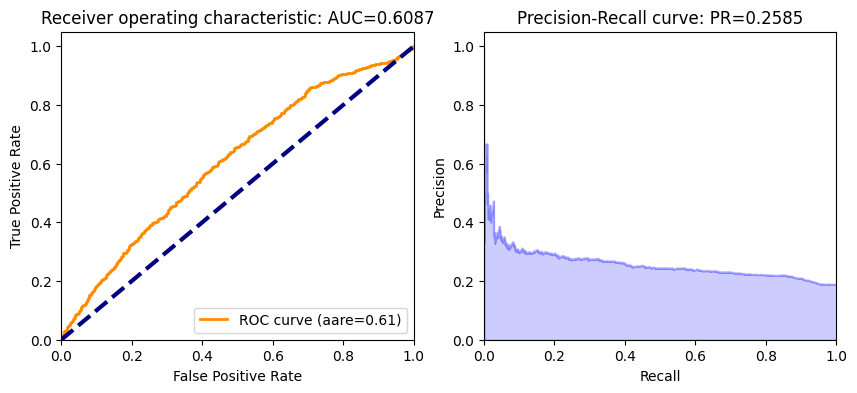

```python
ROC_AUC(gbm_v1,test_hex,'loan_default')
```

```python
#modelfile = rf_v2.download_mojo('rf_v1_mojo',get_genmodel_har=True)
#model_path = h2o.save_model('rf_v1',force=True)
```